# cryptosporidium_riskdraft

Anika Larson

5/10/2016

For this risk estimate, we will use mcmodel and evalmcmod from the [mc2d](https://cran.r-project.org/web/packages/mc2d/index.html) package.

```r
# Load packages.
library(mc2d)
library(data.table)
```

### Define variables

Set the number of simulations for the variability and uncertainty dimensions.

```r
nsv <- 401
nsu <- 100
ndvar(nsv)  # Variability
```

```
## [1] 401
```

```r
ndunc(nsu)   # Uncertainty
```

```
## [1] 100
```

```r
hm <- (nsu/4)
```

The *mc2d* functions will set `nsv` to `ndvar()` and `nsu` to `ndunc()` by default. Alternatively, we could supply these values to the *mc2d* model functions when we call them.

Define the variables we will use to set the `seed` for random sampling and the number of `digits` for `print()` statements.

```r
seed <- 1
digits <- 5
```

Introducing the bootstrapped dose-response data, fread command and sampling from Brian:

```r
alpha <- fread("~/u_drive/envh543/output/alphalist.csv", sep = ',')
n50 <- fread("~/u_drive/envh543/output/N50list.csv", sep = ',')
cdr <- merge(alpha,n50, by = "V1")
scdr <- cdr[sample(nrow(cdr), nsu, replace = TRUE), list(alpha, N50)] #sampling rows in the dose-response bootstrapped table equal to the number of simulations in the uncertainty dimension, aka NSU
```

We will use this variable to explicitly set the seed with the various *mc2d* functions. Another approach would be to only set it through the model evaluation functions, or not at all. Since we want to do our best to provide the most reproducible results, we set the seed explicitly.

### Define exposure model

Within the mcmodel function, use mcstoc to define “mc nodes” for each component of the model.

For each stochastic variable, use the `mcstoc()` function to create a “mcnode”, supply a probability function, the node type as “V” for variability or “U” for uncertainty, and any additional parameters to be passed to the probability function.

For deterministic variables, create nodes with the `mcdata()` function using the “0” type.

The last statement makes an “mc” object using the mc function.

```r
# Define an exposure model for evaluation by evalmcmod().
expo.mod1 <- mcmodel({
  # Values from Example 6.18 from Quantitative Microbial Risk Assessment,
  # 2nd Edition by Charles N. Haas, Joan B. Rose, and Charles P. Gerba.
  # (Wiley, 2014), pp. 215-216. Other fictitious values are noted below.

  # Cistern water viral loading (viruses/L):
  cw.vl_jul92 <- dnorm(hm, mean = 0.75, sd = 1.57)

  cw.vl_jan93 <- dnorm(hm, mean = 11.61, sd = 25.94)

  cw.vl_apr93 <- dnorm(hm, mean = 1.25, sd = 2.59)

  cw.vl_jun93 <- dnorm(hm, mean = 3.52, sd = 4.97)

  huh <- c(cw.vl_jul92, cw.vl_jan93, cw.vl_apr93, cw.vl_jun93)

  cw.vl_seas <- mcstoc(rempiricalD, type = "VU", seed = seed,
                             values = c(0.75, 11.61, 1.25, 3.52), prob = c(0.25, 0.25, 0.25, 0.25))

  # Water consumption (L/day):
  dw.ing <- mcdata(1.466, type = "0")

  # Hosing per event ingestion rate (L/event): worst case estimate = 10mL or .01L per day
  hose.perevent <- mcdata(.01, type = "0")

  # Hosing frequency (hosing/day), fictitious discrete distribution (this basically says that there is a 10% chance someone never hoses, a 70% chance they use the hose every other day, and a 10% chance they use the hose every day) - will be IGNORED for the moment:
  hosing.frequency <- mcstoc(rempiricalD, type = "V", seed = seed,
                             values = c(0, 0.5, 1),
                             prob = c(0.1, 0.7, 0.2))

   # Showering per event ingestion rate (L/event): worst case estimate = 10mL or .01L per day
  shower.perevent <- mcdata(.01, type = "0")

  # Estimate the exposure based ONLY on drinking water ingestion using the 0, V and U nodes to create a VU node.
  expo.mc1 <- (cw.vl_seas * (dw.ing + hose.perevent + shower.perevent))

  #Estimate the risk using a dose-response model pulling from a bootstrapped model of the dose-response
  dose <- mcstoc(rpois, type = "VU", lambda = expo.mc1)

  # Create mcnodes from previously sampled dose-response bootstrap estimates. - Brian

  a <- mcdata(scdr$alpha, type = "U")
  n50 <- mcdata(scdr$N50, type = "U")

  risk <- 1 - (1 + dose*((2^(1/a)-1)/n50))^(-a) #this equation is my version of what came off QMRA Wiki <http://qmrawiki.canr.msu.edu/index.php?title=Dose_response_assessment> and someone should check it -A

  # Build a mc model from all of the mcnode objects.
  mc(cw.vl_seas, dw.ing, hose.perevent, shower.perevent, a, n50, expo.mc1, risk)
})
```

### Evaluate the model

```r
expo.ev1 <- evalmcmod(expo.mod1, seed = seed)
print(expo.ev1, digits = digits)
```

```
##              node    mode nsv nsu nva variate      min       mean
## 1      cw.vl_seas numeric 401 100   1       1  0.75000 4.2778e+00
## 2          dw.ing numeric   1   1   1       1  1.46600 1.4660e+00
## 3   hose.perevent numeric   1   1   1       1  0.01000 1.0000e-02
## 4 shower.perevent numeric   1   1   1       1  0.01000 1.0000e-02
## 5               a numeric   1 100   1       1  0.35789 5.8313e+03
## 6             n50 numeric   1 100   1       1 44.60151 1.4654e+02
## 7        expo.mc1 numeric 401 100   1       1  1.11450 6.3568e+00
## 8            risk numeric 401 100   1       1  0.00000 3.7528e-02
##       median        max Nas type outm
## 1    1.25000 1.1610e+01   0   VU each
## 2    1.46600 1.4660e+00   0    0 each
## 3    0.01000 1.0000e-02   0    0 each
## 4    0.01000 1.0000e-02   0    0 each
## 5 1870.57756 3.1706e+04   0    U each
## 6  138.89792 3.0204e+02   0    U each
## 7    1.85750 1.7252e+01   0   VU each
## 8    0.01829 4.1971e-01   0   VU each
```

### Summarize results

Print a summary and a plot of the evaluation results (`expo.ev1`).

```r
# Summarize the results.
summary(expo.ev1)
```

```
## cw.vl_seas :
##        mean   sd  Min 2.5%   25%  50%   75% 97.5%  Max nsv Na's
## median 4.25 4.37 0.75 0.75 0.750 1.25  3.52  11.6 11.6 401    0
## mean   4.28 4.36 0.75 0.75 0.985 2.14  7.24  11.6 11.6 401    0
## 2.5%   3.92 4.16 0.75 0.75 0.750 1.25  3.52  11.6 11.6 401    0
## 97.5%  4.69 4.56 0.75 0.75 1.250 3.52 11.61  11.6 11.6 401    0
##
## dw.ing :
##       NoUnc
## NoVar  1.47
##
## hose.perevent :
##       NoUnc
## NoVar  0.01
##
## shower.perevent :
##       NoUnc
## NoVar  0.01
##
## a :
##           NoVar
## median 1.87e+03
## mean   5.83e+03
## 2.5%   5.39e-01
## 97.5%  2.52e+04
##
## n50 :
##        NoVar
## median 138.9
## mean   146.5
## 2.5%    67.2
## 97.5%  239.3
##
## expo.mc1 :
##        mean   sd  Min 2.5%  25%  50%   75% 97.5%  Max nsv Na's
## median 6.32 6.49 1.11 1.11 1.11 1.86  5.23  17.3 17.3 401    0
## mean   6.36 6.48 1.11 1.11 1.46 3.17 10.76  17.3 17.3 401    0
## 2.5%   5.83 6.18 1.11 1.11 1.11 1.86  5.23  17.3 17.3 401    0
## 97.5%  6.98 6.77 1.11 1.11 1.86 5.23 17.25  17.3 17.3 401    0
##
## risk :
##          mean     sd Min 2.5%     25%     50%    75%  97.5%    Max nsv
## median 0.0343 0.0369   0    0 0.00565 0.01691 0.0537 0.1155 0.1442 401
## mean   0.0375 0.0392   0    0 0.00662 0.02001 0.0596 0.1260 0.1543 401
## 2.5%   0.0168 0.0184   0    0 0.00290 0.00869 0.0244 0.0606 0.0728 401
## 97.5%  0.0842 0.0845   0    0 0.01670 0.04915 0.1359 0.2740 0.3079 401
##        Na's
## median    0
## mean      0
## 2.5%      0
## 97.5%     0
```

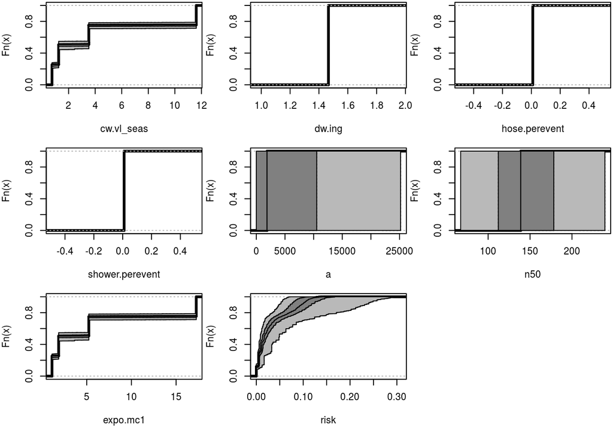

```r
# Plot the results.
plot(expo.ev1)
```

Report the mean and median of the exposure means with a 95% confidence interval (CI95).

```r
mean.expo <- sapply(1:ndunc(), function(j) mean(expo.ev1$expo.mc1[, j, ]))
mean(mean.expo)
```

```
## [1] 6.356756
```

```r
quantile(mean.expo, probs = seq(0, 1, 0.025))[c("2.5%", "50%", "97.5%")]
```

```
##     2.5%      50%    97.5%
## 5.825693 6.316074 6.976562
```

Report the mean and median of the risk probability means with a 95% confidence interval (CI95).

```r
mean.risk <- sapply(1:ndunc(), function(j) mean(expo.ev1$risk[, j, ]))
mean(mean.risk)
```

```
## [1] 0.03752769
```

```r
quantile(mean.risk, probs = seq(0, 1, 0.025))[c("2.5%", "50%", "97.5%")]
```

```
##       2.5%        50%      97.5%
## 0.01682729 0.03429294 0.08422717
```

Plot the empirical cumulative distribution function (ecdf) of the exposure model (`expo.mc1`) estimates.

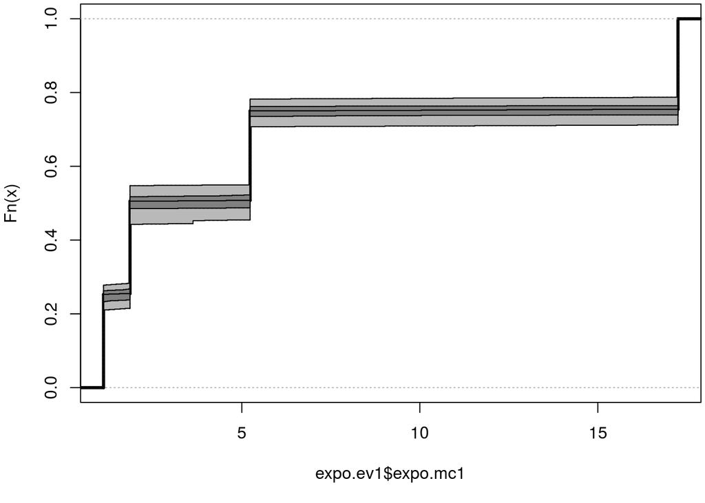

```r
# Generate an "ecdf" plot. This actually calls plot.mcnode().
plot(expo.ev1$expo.mc1)
```

Plot the empirical cumulative distribution function (ecdf) of the risk model (`risk`) estimates.

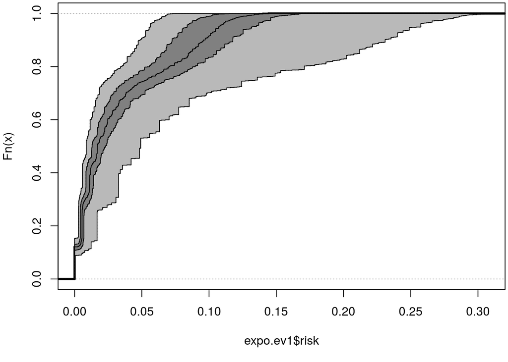

```r
# Generate an "ecdf" plot. This actually calls plot.mcnode().
plot(expo.ev1$risk)
```

So if we did this right, could the plot above can be correctly labeled as follows?

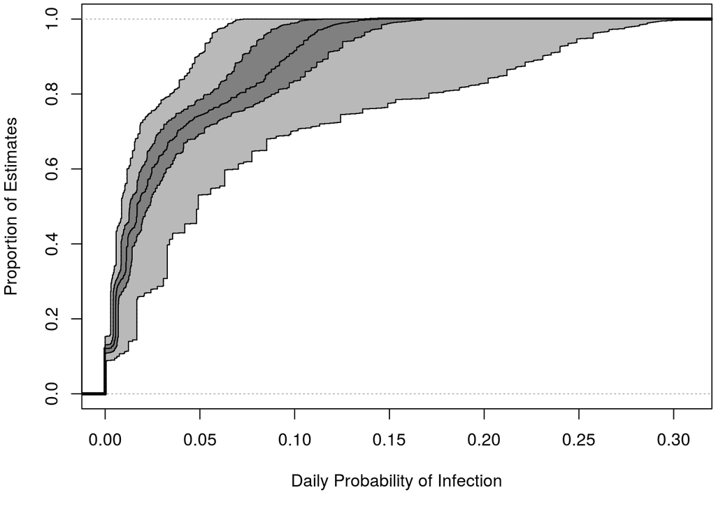

```r
# Generate an "ecdf" plot. This actually calls plot.mcnode().
plot(expo.ev1$risk, main = "", ylab = "Proportion of Estimates", xlab = "Daily Probability of Infection")
title("Daily Infec. Risk with Cryptosporidium by RCRW
in the USVI", cex.main = 1, font.main= 1, line = 7)
```

Questions: